# Randomization Distributions and Hypothesis Testing, Continued

Day 16

Claire Kelling

Carleton College  
STAT 120 - Fall 2026

## Question of the Day

Sit anywhere this week!

If you could instantly learn any skill, what would it be?

## Today’s Topics

Housekeeping:

- Final report groups posted soon!
- Quiz 2 grades posted today: reminder of corrections policy
- Revised AI Agreement and Quiz 1 Corrections due today

Topics covered today:

- Midterm Evaluation Recap
- Randomization Distributions
- Implementation of Randomization Distributions in R

## Quiz note

Hypotheses are about population parameters!

BUT note that the information from the **sample** is/is not statistically discernible (from the null), not the population. (Reading Check 10, Question 1)

## Midterm Evaluation

- What is going well
  - Note packets, balance/structure of homework assignments
  - Activities in class
  - Handouts as a resource after class, working with different people
  - Clarity of expectations (including Moodle)
  - R Lab Manual!
- Ideas for the future
  - Videos- this is challenging! It should be easier once we get past simulation-based inference. I will try to find a video that covers some of the major material.
  - *More time to practice R in class and more in-group examples*: yes!
  - *More info on R*: Yes, but also STAT 220 might be a good opportunity!
  - Many of you want to meet with each other more often outside of class!
  - References to examples: please let me know if you can’t find anything!
- Love/hate relationship with R
  - Summary of R functions in the Lab Manual
- Some feel the class is going too slow and others feel too fast…

## Midterm Evaluation

- Thank you for your feedback!!
  - Remember anonymous feedback form at any time :)
  - And would welcome additional conversation in my office!

# Alternative Hypotheses

## P-value and Alternative Hypothesis

- The p-value is the proportion in the tail in the direction specified by $H_a$
- For a two-sided alternative, the p-value is **twice the proportion in the** **smallest tail** (so you avoid p-value > 1)

## P-value and Alternative Hypothesis

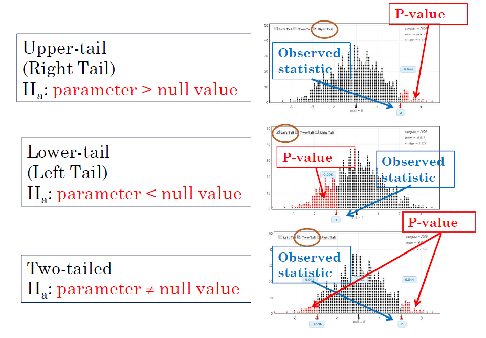

## Reference Distribution

**Randomization Distribution as a Reference**

- We can think of the permutation (randomization) distribution as a reference.
- It is an approximation of the distribution of the statistic when the null hypothesis holds.
- We compare this distribution to the **observed** statistic.

## P-value Example: Correlation

Use the randomization distribution below to test:

$H_0: \rho = 0$ $H_a: \rho >0$

- Randomization distribution includes statistics simulated from the **null hypothesis.** Where will my randomization distribution be centered?
- Match the sample correlation and p-values:

**Sample correlation**: $r = 0.1$, $r=0.3$, $r=0.5$

**P-values**: 0.005, 0.15, 0.35

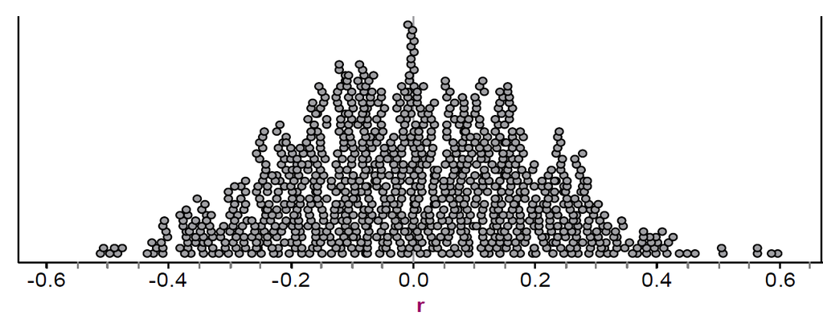

Randomization Distribution (under $H_0$)

# Implementation

## Permutation Tests in StatKey

[figure not shown]

## Permutation Tests in StatKey: Carleton Basketball

**Two-sided test**

- $H_0: \mu_A = \mu_H$, $H_a: \mu_A \neq \mu_H$
- $\bar{x}_A - \bar{x}_H$ = 3.8 degrees
- p-value = **0.163 + 0.163** = 0.326

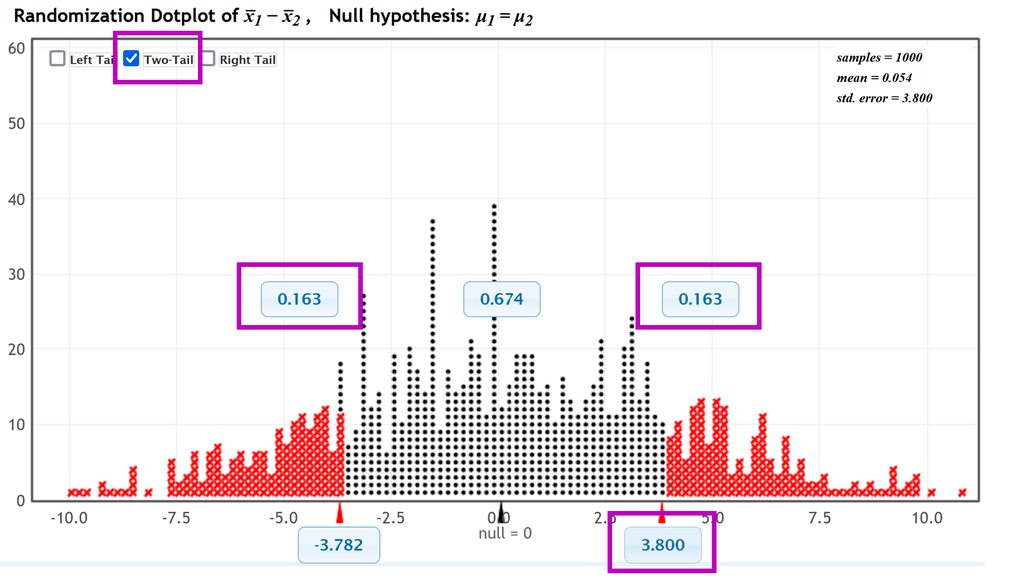

## Permutation Tests in R

- Difference in means/proportion by factor variable
- Alternative can be two.sided (default), greater, less

```r
library(CarletonStats)
permTest(numeric ~ factor, data = dataset,
            alt = "greater")
```

## Permutation Tests in R: Carleton Basketball

```r
library(CarletonStats)
permTest(Spread ~ Home.Away, data = carleton_bball, alternative = "greater")
```

```
    ** Permutation test **

 Permutation test with alternative: greater
 Observed mean
  Away :  10.75      Home :  7
 Observed difference: 3.75

 Mean of permutation distribution: -0.03104
 Standard error of permutation distribution: 3.85096
 P-value:  0.1793

    *-------------*
```

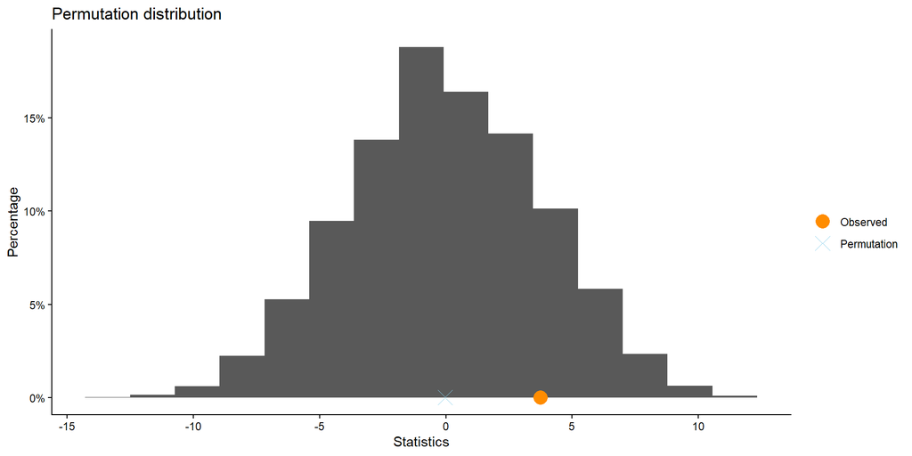

## Handout

Let’s run through Exercise 1 (and 2 if you have time) in small groups. You’ll adapt R code for 1b, and use Statkey for other exercises.

# Randomization Distribution

## Permutation/Randomization Distributions

**Definition**

A **randomization distribution** is a collection of statistics from samples simulated assuming the *null hypothesis is true.*

Some general principles of randomization distributions:

1. The null hypothesis is assumed to be true
2. Try to mirror the structure of the original data (through resampling, for example)

Can use the randomization distribution to generate a **p-value** for a given hypothesis test.

## Recall the Carleton Basketball Team

**If there is no advantage to being away, the distribution of spreads which occurred, shown below**

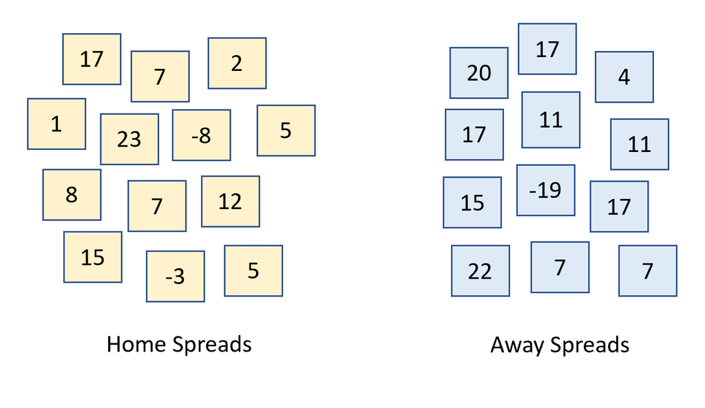

$\bar{x}_A = 10.8$, $\bar{x}_H = 7$ so $\bar{x}_A - \bar{x}_H = 3.8$ (observed sample statistic)

**could just as easily have been:**

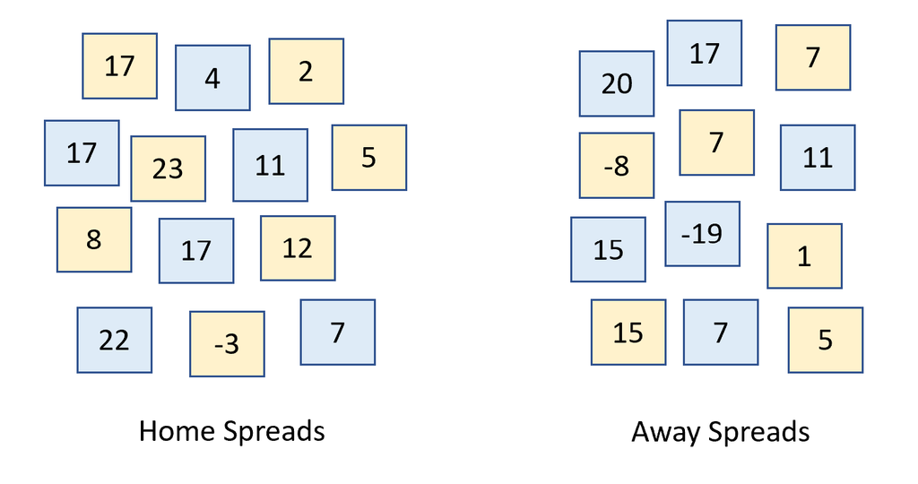

This is called a resample.

$H_0$: group membership arbitrary (no effect on response).

## Comparing Groups in General

Randomization distribution for comparing two groups (1 and 2)

- Null: $H_0: \mu_1 - \mu_2 = 0$ OR $H_0: p_1 - p_2 = 0$
- Response (the $x$’s below) can be categorical or quantitative
- Creating a randomization distribution consistent with $H_0$: **group membership arbitrary (no effect on response)**
1. **Randomly permute (rerandomize)** the group assignment for all cases
2. Compute the sample mean/proportion for each group and find the difference, denoted $\bar{x}_1 - \bar{x}_2$ OR $\hat{p}_1 - \hat{p}_2$
3. Repeat lots of times

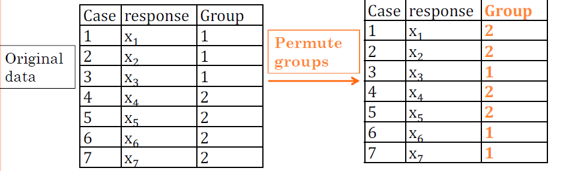

## Randomization Dist for Correlation

- Null: $H_0: \rho = 0$ OR $H_0: \beta=0$
- Creating a randomization distribution consistent with $H_0$: **no association between x and y**. How?
1. **Randomly permute (rerandomize)** one of the variables (either x or y)
2. Compute the sample correlation/slope, r or b.
3. Repeat lots of times

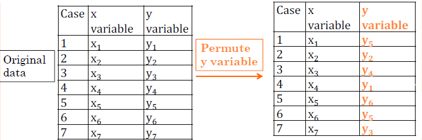

## Mercury and pH in Lakes

- For Florida lakes, are lower pH levels (more acidity) associated with higher mercury levels?

$H_0:$ $\beta = 0$ vs $H_a:$ $\beta < 0$

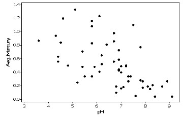

The regression line slope for our sample is b = -0.152.

Lange, Royals, and Connor, Transactions of the American Fisheries Society (1993)

## Mercury and pH in Lakes

$$H_0: \beta = 0 \text{ vs } H_a: \beta < 0$$

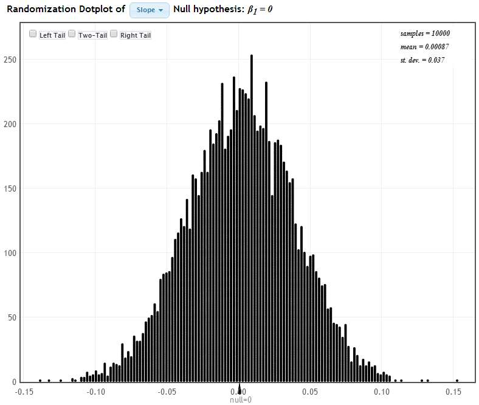

- How was this randomization distribution generated?
- How do we find the p-value? (b = -0.152)

## Mercury and pH in Lakes

- **How do we find the p-value?**
  - p-value: Chance of getting a slope as small, or smaller than, the observed slope of b = -0.152.
- **Conclusion:** Yes, higher pH levels are discernibly associated with lower mercury levels (pvalue < 0.0001).

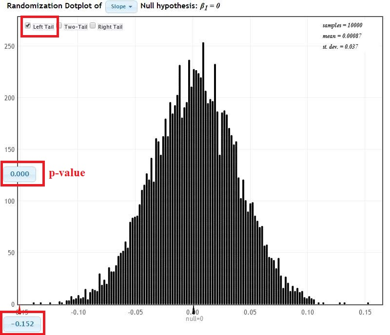

Let’s do it in R! Example 3.

## Mercury and pH in Lakes

- How much lower? How do we estimate this?
- **Bootstrap distribution for the slope**
- Interpretation: We are 95% confident that the true predicted mercury level will decrease by 0.1 to 0.2 units for each 1 unit increase in pH.

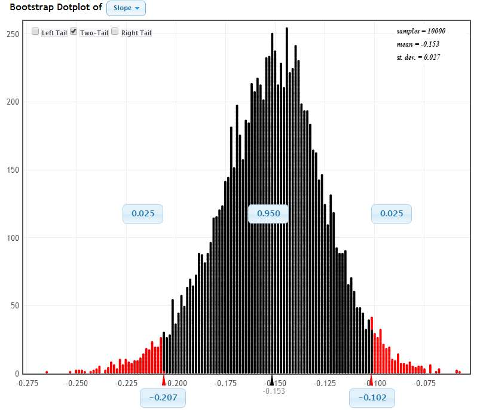

## Randomization Distribution for Paired Data

**Tuition Data**

- We want to know if the average tuition charged to non-residents is higher than residents for all state colleges and universities
- Population: all state colleges and universities

**Hypotheses**

- Parameters: $\mu$ = mean tuition (resident or nonresident) for all colleges and universities
- $H_0: \mu_{non-resident} - \mu_{resident} = 0$
- $H_a: \mu_{non-resident} - \mu_{resident} > 0$
- Data: **paired** tuition amounts (resident, nonresident) from a random sample of n=19 schools
- (Basketball data was not paired: games were individ obs)

## Paired Tuitions

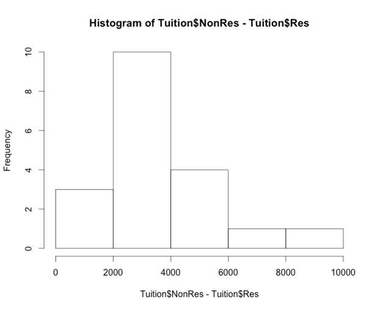

Paired Differences

## Tuition: Resident vs Non-Resident

- $H_0: \mu_{non-resident} - \mu_{resident} = 0$
- $H_a: \mu_{non-resident} - \mu_{resident} > 0$

How might we create a randomization distribution for paired data?

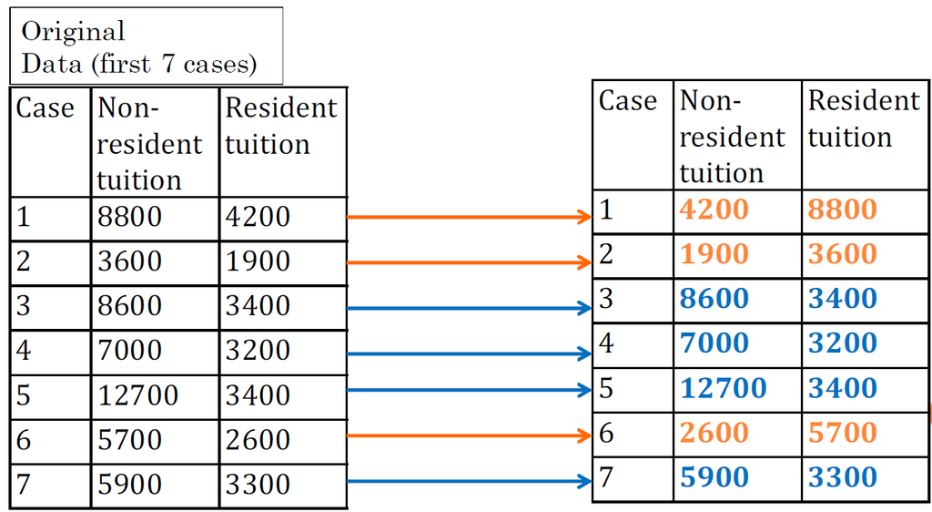

## Tuition: Resident vs Non-Resident

- $H_0: \mu_{non-resident} - \mu_{resident} = 0$
- $H_a: \mu_{non-resident} - \mu_{resident} > 0$

How might we create a randomization distribution for paired data?

1. Randomly reassign tuition amounts to resident or non-resident for each case
2. Calculate the mean difference, $\bar{x}_{non-resident} - \bar{x}_{resident}$
3. Repeat lots of times

Let’s do it in R! Example 4.

## Paired Perm Dist in R

**Code and Output, Paired Perm Dist**

```r
permTestPaired(NonRes ~ Res, data = tuition, alt = "greater")
```

```
    ** Permutation test **

 Permutation test with alternative: greater
 Observed mean
  Res :  2821.053    NonRes :  6405.263
 Observed difference: 3584.211

 Mean of permutation distribution: -3.07136
 Standard error of permutation distribution: 942.0064
 P-value:  0.0001

    *-------------*
```

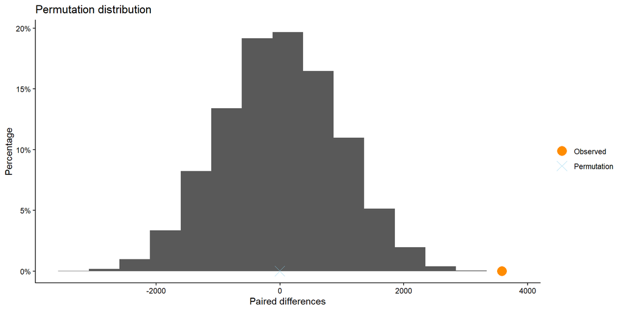

## Paired Perm Dist in R

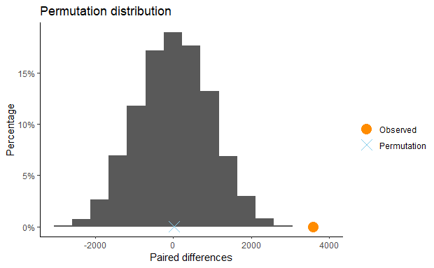

(Output from function)

## Paired Perm Dist in R

**Interpretation**

## Summary

- The randomization distribution shows what types of statistics would be observed, just by random chance, if the null hypothesis were true
- A **p-value** is the chance of getting a statistic as or more extreme as that observed, if $H_0$ is true
- A p-value can be calculated as the proportion of statistics in the randomization distribution as or more extreme as the observed sample statistic
- The smaller the p-value, the greater the evidence against $H_0$

## Next Class

Finishing content from today!